# PW5_DecisionTrees_-_RandomForests.r

anais

2020-12-08

# Regression Trees

## Single tree

### 1 Load the Boston dataset from MASS package. Split the dataset randomly in half.

```r
library(MASS)
library(caTools)
set.seed(18)
Boston_idx = sample(1:nrow(Boston), nrow(Boston) / 2)
Boston_train = Boston[Boston_idx,]
Boston_test  = Boston[-Boston_idx,]
```

### 2 Fit a regression tree to the training data using the rpart() function from the rpart package. Name the tree Boston_tree.

```r
library(rpart)
Boston_tree <- rpart(medv ~ ., data = Boston_train)
```

### 3 Plot the obtained tree using the following code.

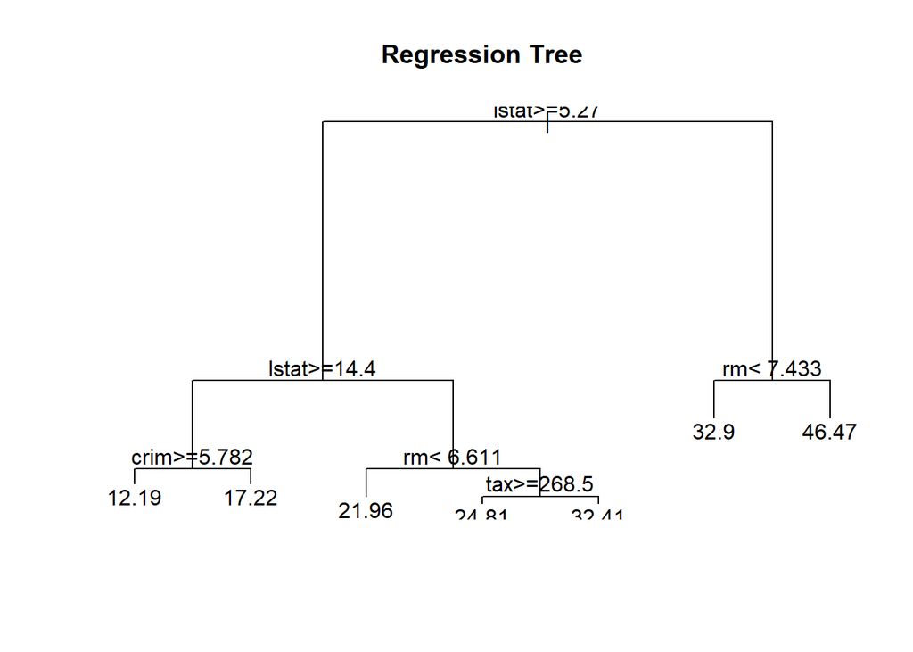

```r
plot(Boston_tree)
text(Boston_tree, pretty = 0)
title(main = "Regression Tree")
```

### 4 A better plot can be obtained using the rpart.plot18 package. Re-plot the tree using it.

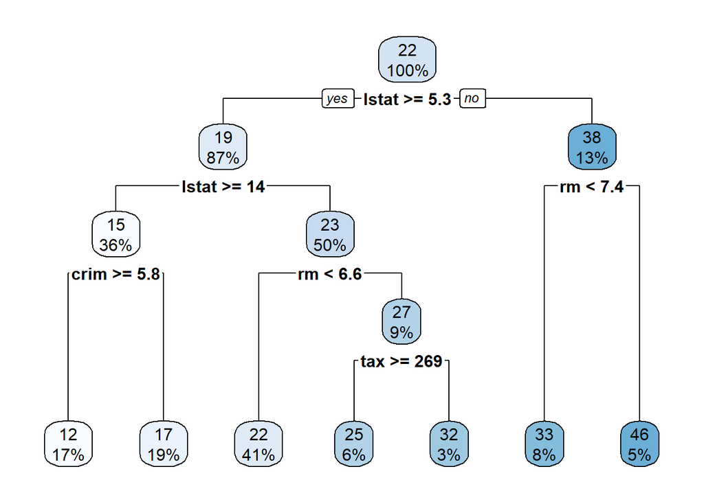

```r
#You can use the rpart.plot() function which by default, when the output is continuous,
#each node shows: the predicted value, and the percentage of observations in the node. You can also use the prp() function.


library(rpart.plot)
# second visualization of the tree
rpart.plot(Boston_tree)
```

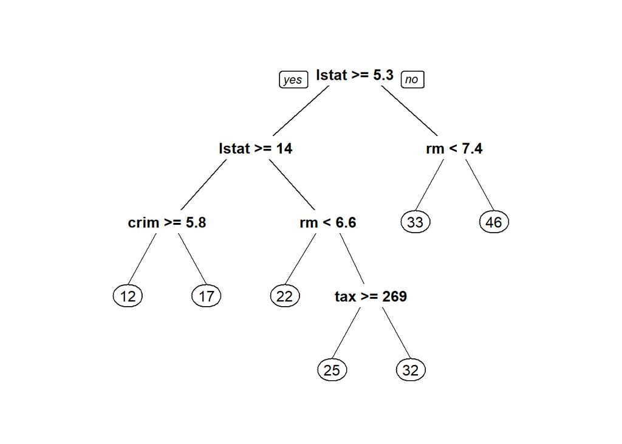

```r
# third one
prp(Boston_tree)
```

### 5 Print the obtained tree and print its summary. Between the things that you can see in the summary,

```r
#the CP (complexity parameter) table and the importance of each variable in the model.
#Print the CP table using the printcp() function to see the cross validation results. Plot a comparison figure using the plotcp() function.

Boston_tree
```

```
## n= 253
##
## node), split, n, deviance, yval
##       * denotes terminal node
##
##  1) root 253 19858.11000 21.99802
##    2) lstat>=5.27 219  7420.35000 19.49954
##      4) lstat>=14.4 92  1798.17900 14.81522
##        8) crim>=5.7819 44   648.06430 12.18864 *
##        9) crim< 5.7819 48   568.30480 17.22292 *
##      5) lstat< 14.4 127  2141.02400 22.89291
##       10) rm< 6.611 104   991.45380 21.95769 *
##       11) rm>=6.611 23   647.29910 27.12174
##         22) tax>=268.5 16   268.14940 24.80625 *
##         23) tax< 268.5 7    97.28857 32.41429 *
##    3) lstat< 5.27 34  2265.02700 38.09118
##      6) rm< 7.433 21   686.16950 32.90476 *
##      7) rm>=7.433 13   101.48770 46.46923 *
```

```r
summary(Boston_tree)
```

```
## Call:
## rpart(formula = medv ~ ., data = Boston_train)
##   n= 253
##
##           CP nsplit rel error    xerror       xstd
## 1 0.51227092      0 1.0000000 1.0079237 0.12063261
## 2 0.17530106      1 0.4877291 0.6269968 0.08009188
## 3 0.07439632      2 0.3124280 0.4181044 0.06301976
## 4 0.02929834      3 0.2380317 0.3886623 0.06765051
## 5 0.02529297      4 0.2087334 0.3489906 0.06171012
## 6 0.01419376      5 0.1834404 0.3172825 0.05624605
## 7 0.01000000      6 0.1692466 0.3051705 0.05617950
##
## Variable importance
## lstat    rm   age   tax   dis indus   nox  crim   rad    zn black
##    40    17     9     7     7     6     5     5     2     1     1
##
## Node number 1: 253 observations,    complexity param=0.5122709
##   mean=21.99802, MSE=78.49055
##   left son=2 (219 obs) right son=3 (34 obs)
##   Primary splits:
##       lstat   < 5.27    to the right, improve=0.5122709, (0 missing)
##       rm      < 6.978   to the left,  improve=0.4501026, (0 missing)
##       indus   < 7.625   to the right, improve=0.3122330, (0 missing)
##       ptratio < 19.65   to the right, improve=0.2830922, (0 missing)
##       nox     < 0.5125  to the right, improve=0.2710296, (0 missing)
##   Surrogate splits:
##       rm    < 6.978   to the left,  agree=0.917, adj=0.382, (0 split)
##       age   < 17.1    to the right, agree=0.881, adj=0.118, (0 split)
##       crim  < 0.03402 to the right, agree=0.877, adj=0.088, (0 split)
##       zn    < 87.5    to the left,  agree=0.870, adj=0.029, (0 split)
##       indus < 1.605   to the right, agree=0.870, adj=0.029, (0 split)
##
## Node number 2: 219 observations,    complexity param=0.1753011
##   mean=19.49954, MSE=33.88288
##   left son=4 (92 obs) right son=5 (127 obs)
##   Primary splits:
##       lstat   < 14.4    to the right, improve=0.4691352, (0 missing)
##       crim    < 5.84803 to the right, improve=0.3530712, (0 missing)
##       ptratio < 19.9    to the right, improve=0.3072113, (0 missing)
```

[output cut: 74 more lines]

```
##       tax     < 268.5   to the right, improve=0.4354419, (0 missing)
##       ptratio < 18.7    to the right, improve=0.3278305, (0 missing)
##       indus   < 4.415   to the right, improve=0.2124938, (0 missing)
##       rm      < 6.978   to the left,  improve=0.1449609, (0 missing)
##       nox     < 0.5225  to the right, improve=0.1122918, (0 missing)
##   Surrogate splits:
##       indus   < 2.21    to the right, agree=0.783, adj=0.286, (0 split)
##       rm      < 7.1455  to the left,  agree=0.783, adj=0.286, (0 split)
##       ptratio < 13.9    to the right, agree=0.783, adj=0.286, (0 split)
##
## Node number 22: 16 observations
##   mean=24.80625, MSE=16.75934
##
## Node number 23: 7 observations
##   mean=32.41429, MSE=13.89837
```

```r
printcp(Boston_tree)
```

```
##
## Regression tree:
## rpart(formula = medv ~ ., data = Boston_train)
##
## Variables actually used in tree construction:
## [1] crim  lstat rm    tax
##
## Root node error: 19858/253 = 78.491
##
## n= 253
##
##         CP nsplit rel error  xerror     xstd
## 1 0.512271      0   1.00000 1.00792 0.120633
## 2 0.175301      1   0.48773 0.62700 0.080092
## 3 0.074396      2   0.31243 0.41810 0.063020
## 4 0.029298      3   0.23803 0.38866 0.067651
## 5 0.025293      4   0.20873 0.34899 0.061710
## 6 0.014194      5   0.18344 0.31728 0.056246
## 7 0.010000      6   0.16925 0.30517 0.056180
```

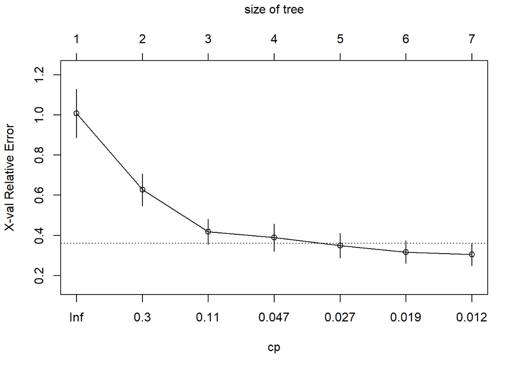

```r
plotcp(Boston_tree)
```

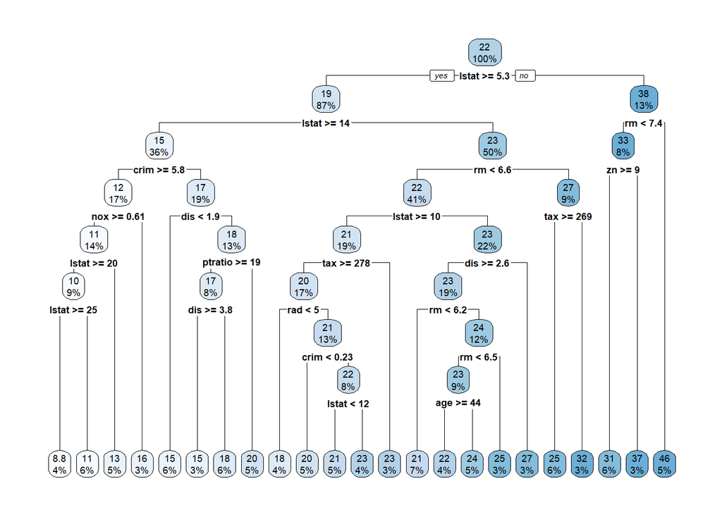

```r
# Full grown tree, using cp = -1
Boston_full_tree <- rpart(medv ~ ., data = Boston_train, cp = -1)
rpart.plot(Boston_full_tree)
```

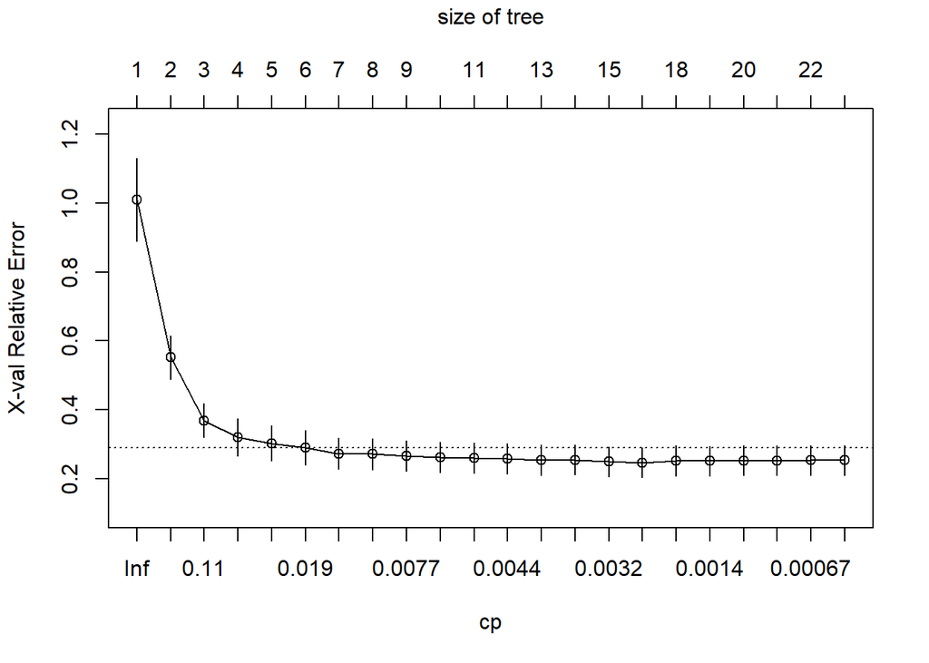

```r
plotcp(Boston_full_tree)
```

### 6 Write a Rfunction that returns the RMSE of two vector

```r
RMSE <- function(expected, observed)
{
  return(sqrt( mean( (expected-observed)^2  ) ))
}
```

### 7 Use the function predict() to predict the response on the test set. Then calculate the RMSE obtained with tree model.

```r
Boston_tree_predict <- predict(Boston_tree, Boston_test)
Boston_tree_RMSE = RMSE(Boston_tree_predict,Boston_test$medv)
Boston_tree_RMSE
```

```
## [1] 5.051138
```

### 8 Fit a linear regression model on the training set. Then predict the response on the test set using the linear model.

```r
#Calculate the RMSE and compare the performance of the tree and the linear regression model.

Boston_regression <- lm(medv ~ ., data = Boston_train)
Boston_regression_predict <- predict(Boston_regression, Boston_test)
Boston_regression_RMSE = RMSE(expected = Boston_regression_predict,observed = Boston_test$medv)
Boston_regression_RMSE
```

```
## [1] 5.016083
```

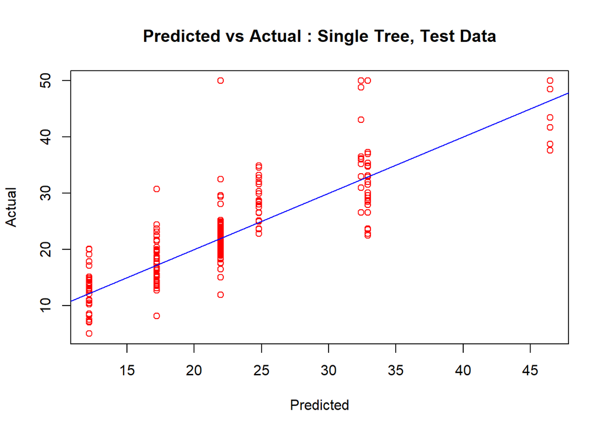

```r
# We obtain a really slightly best RMSE with the linear model : 5.051138 (tree) vs 5.016083 (regression)

# Model performance plot
plot(Boston_tree_predict,Boston_test$medv,col='red',pch=21,
     xlab = "Predicted",
     ylab = "Actual",
     main = "Predicted vs Actual : Single Tree, Test Data")
abline(0,1,col='blue')
```

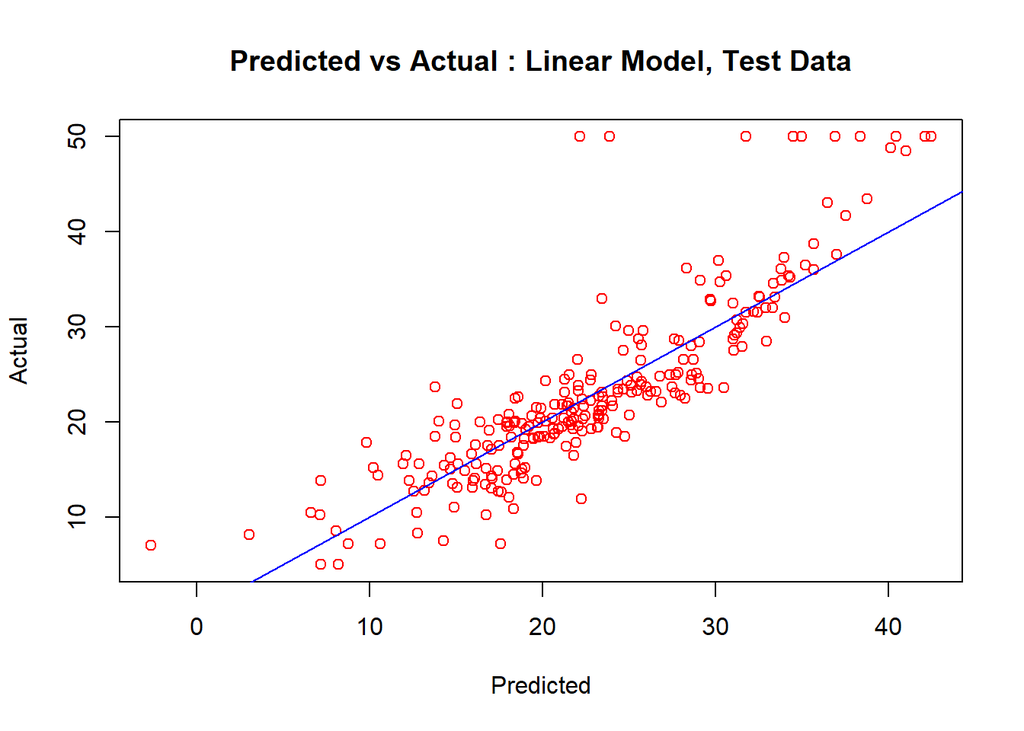

```r
plot(Boston_regression_predict,Boston_test$medv,col='red',pch=21,
     xlab = "Predicted",
     ylab = "Actual",
     main = "Predicted vs Actual : Linear Model, Test Data")
abline(0,1,col='blue')
```